# MULTIPARAMETER MODELS

Sylvia Ye

## Question 1 (Charpter 3 Problem 4)

Inference for a 2 × 2 table: an experiment was performed to estimate the effect of beta- blockers on mortality of cardiac patients. A group of patients were randomly assigned to treatment and control groups: out of 674 patients receiving the control, 39 died, and out of 680 receiving the treatment, 22 died. Assume that the outcomes are independent and binomially distributed, with probabilities of death of p0 and p1 under the control and treatment, respectively.

1. Set up a noninformative prior distribution on (p0, p1) and obtain posterior simulations.

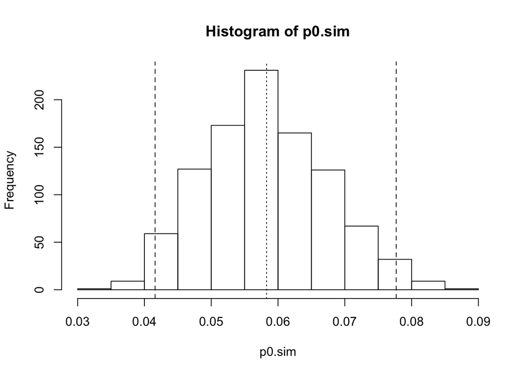

```r
# Data
n_0 <- 674
y_0 <- 39
n_1 <- 680
y_1 <- 22

# Uniform priors of p0 and p1
alpha_0 <- 1
beta_0 <- 1
alpha_1 <- 1
beta_1 <- 1

# Posterior distribution of p0 and p1
# Model:
# y1 ~ Binomial(n1, p1)
# y2 ~ Binomial(n2, p2)

S = 1000
set.seed(0)
p0.sim <- rbeta(S, alpha_0 + y_0, beta_0 + n_0 - y_0)
p1.sim <- rbeta(S, alpha_1 + y_1, beta_1 + n_1 - y_1)

hist(p0.sim)
temp <- quantile(p0.sim, c(.025, .975))
abline(v=temp, lty=2)
abline(v=mean(p0.sim), lty = 3)
```

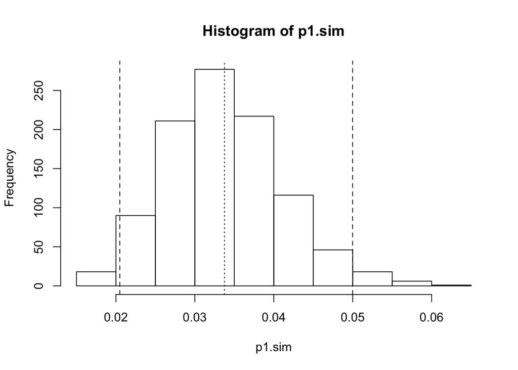

```r
hist(p1.sim)
temp <- quantile(p1.sim, c(.025, .975))
abline(v=temp, lty=2)
abline(v=mean(p1.sim), lty = 3)
```

From the simulation we can see that: The mean of p0 is 0.0583 and the 95% CI for p0 is [0.0416, 0.0777]. The mean of p1 is 0.0338 and the 95% CI for p1 is [0.0205, 0.0500].

2. Summarize the posterior distribution for the odds ratio, (p1/(1-p1))/(p0/(1-p0))

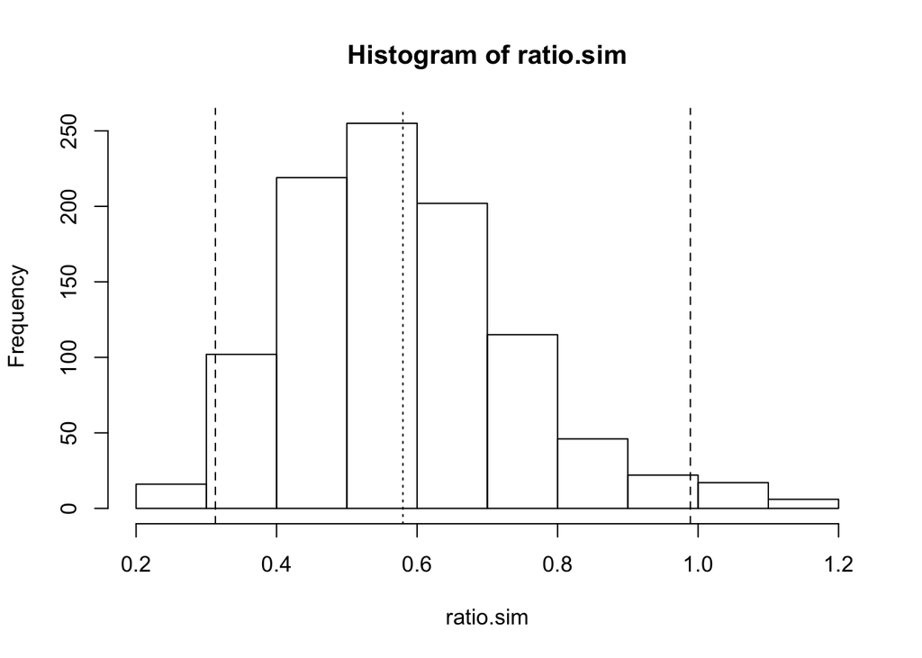

```r
ratio.sim <- p1.sim * (1-p0.sim) / ( p0.sim * (1-p1.sim) )
hist(ratio.sim)
temp <- quantile(ratio.sim, c(.025, .975))
abline(v=temp, lty=2)
abline(v=mean(ratio.sim), lty = 3)
```

From above we can see that the 95% CI of theta is [0.313, 0.989], all the area is below 1. So we can conclude that the treatment is efficient.

## Question 2: (Charpter 3 Problem 11)

In the bioassay example, replace the uniform prior density by a joint nor- mal prior distribution on (alpha, beta), with alpha ∼ N(0, 22), beta ∼ N(10, 102), and corr(alpha, beta)=0.5.

Model:
$$y_i|\theta - Binomial(n_i, p_i)$$
$$logit(\theta_i) = log(\frac{\theta_i}{1 - \theta_i}) = \alpha + \beta x_i$$
$$\alpha ～ N(0, 22)$$
$$\beta ～ N(10, 102)$$
$$Corr(\alpha, \beta) = 0.5$$

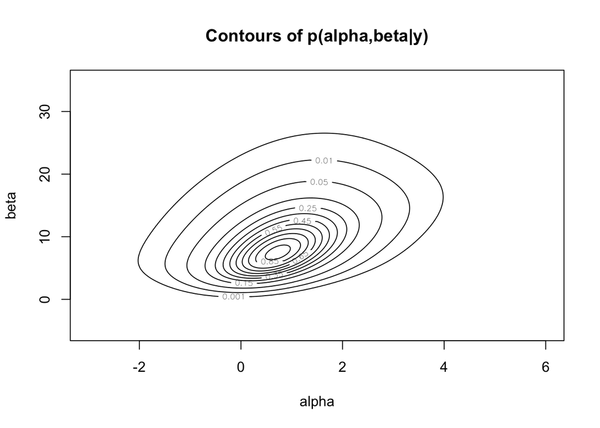

```r
library(boot)

# Key in data
x <- c(-.86, -.30, -.05, .73)
n <- c(5, 5, 5, 5)
y <- c(0, 1, 3, 5)

# hyperprior parameters
m.a <- 0
s.a <- 2
m.b <- 10
s.b <- 10
rho <- 0.50
alpha <- seq(-3, 6, .05)
beta <- seq(-5, 35, .20)
I <- length(alpha)
J <- length(beta)

# Posterior
log.post <- matrix(rep(NA, I*J), I, J)
for(i in 1:I){ for(j in 1:J){
  a <- alpha[i]; b <- beta[j];
  z.a <- (a - m.a)/s.a; z.b <- (b - m.b)/s.b;
  log.prior <- -0.5 * (z.a^2 + z.b^2 + 2*rho*z.a*z.b) / (1-rho^2)
  theta <- inv.logit(a + b * x)
  log.like <- sum(dbinom(y, n, theta, log=T))
  log.post[i,j] <- log.like + log.prior
}}
temp <- max(log.post)
log.post <- log.post - temp
post <- exp(log.post)

# Contour plot
contours <- c(.001, .01, seq(.05, .95, .10))
contour(alpha, beta, post, levels=contours, xlab="alpha", ylab="beta",
        main="Contours of p(alpha,beta|y)")
```

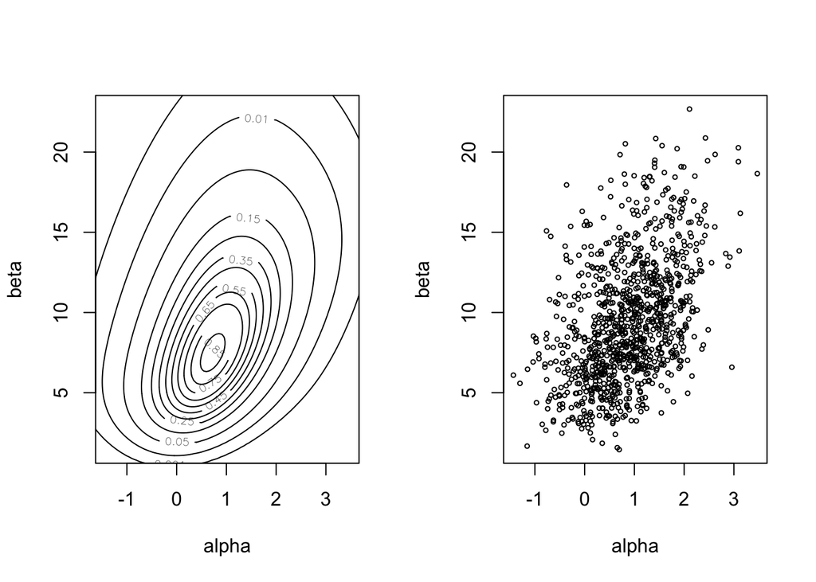

```r
# Sample for posterior
delta = (alpha[2]-alpha[1])/2
epsilon = (beta[2]-beta[1])/2
post.a = apply(post,1,sum)

S = 1000
alpha.sim = rep(NA,S)
beta.sim = rep(NA,S)
for(s in 1:S){
  i = sample(I,1,prob = post.a)
  j = sample(J,1,prob = post[i,])
  alpha.sim[s] = alpha[i]+runif(1,-delta,delta)
  beta.sim[s] = beta[j]+runif(1,-epsilon,epsilon)
}

# Display the contour and scatterplot
par(mfrow = c(1,2))
contour(alpha,beta,post,levels = contours, xlim=range(alpha.sim), ylim=range(beta.sim),
        xlab="alpha", ylab="beta")
plot(alpha.sim,beta.sim,xlim = range(alpha.sim),ylim = range(beta.sim),cex = 0.5,
     xlab="alpha", ylab="beta")
```

From the plot above, we can conclude that the contour plot and scatterplot look like a compromise between the prior distribution and the likelihood.

```r
mean(beta.sim > 0)
```

```
## [1] 1
```

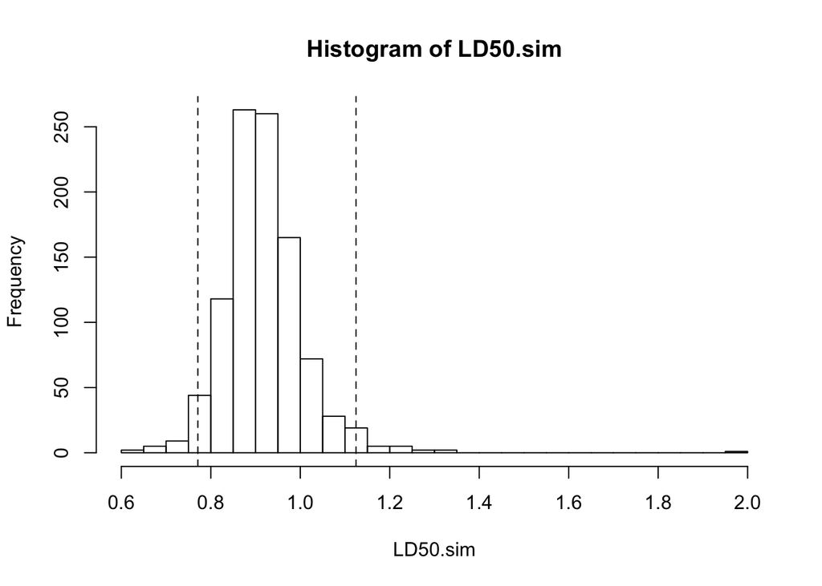

```r
LD50.sim = exp(-alpha.sim / beta.sim)
hist(LD50.sim, breaks=20)
temp <- quantile(LD50.sim, c(.025, .975))
abline(v=temp, lty=2)
```

```r
temp
```

```
##      2.5%     97.5%
## 0.7710343 1.1246273
```

From the results above, we can conclude that:

1, The posterior probability beta > 0 is almost 1. So we can say that the drug is harmful.

2, LD50, the dose level at which the probability of death is 50%, can be calculated by LD50 = exp(-alpha/beta). From the simulation above, the 95% posterior interval for LD50 is [0.771, 1.125]

## Question 3: (Charpter 3 Problem 12)

Poisson regression model: expand the model of Exercise 2.13(a) by assuming that the number of fatal accidents in year t follows a Poisson distribution with mean α + βt. You will estimate α and β, following the example of the analysis in Section 3.7.

1. Calculate crude estimates and uncertainties for (α,β) using linear regression.

```r
y <- c(24, 25, 31, 31, 22, 21, 26, 20, 16, 22)
t <- 1:10

ml<- glm(y~t,family = poisson(link = "log"))
summary(ml)
```

```
##
## Call:
## glm(formula = y ~ t, family = poisson(link = "log"))
##
## Deviance Residuals:
##     Min       1Q   Median       3Q      Max
## -1.0656  -0.4573  -0.3639   0.6877   1.1416
##
## Coefficients:
##             Estimate Std. Error z value Pr(>|z|)
## (Intercept)  3.37691    0.13407  25.188   <2e-16 ***
## t           -0.03880    0.02265  -1.713   0.0867 .
## ---
## Signif. codes:  0 '***' 0.001 '**' 0.01 '*' 0.05 '.' 0.1 ' ' 1
##
## (Dispersion parameter for poisson family taken to be 1)
##
##     Null deviance: 8.3893  on 9  degrees of freedom
## Residual deviance: 5.4439  on 8  degrees of freedom
## AIC: 59.413
##
## Number of Fisher Scoring iterations: 4
```

```r
# point estimates +/- 5 SEs
3.3769+c(-5,5)*0.1341 # alpha
```

```
## [1] 2.7064 4.0474
```

```r
-0.0388+c(-5,5)*0.02265 # beta
```

```
## [1] -0.15205  0.07445
```

From above we can see that:

The estimate of alpha is 3.3769, the standard deviation of alpha is 0.1341. The estimate of beta is -.0388, the standard deviation of beta is .02265. P-value of beta is 0.0867, so we have 90% confidence to reject that beta = 0.

Moreover, alpha in [2.5, 4.0] and beta in [-.15, .10] should contain almost all of the posterior probability.

2. Plot the contours and take 1000 draws from the joint posterior density of (α,β).

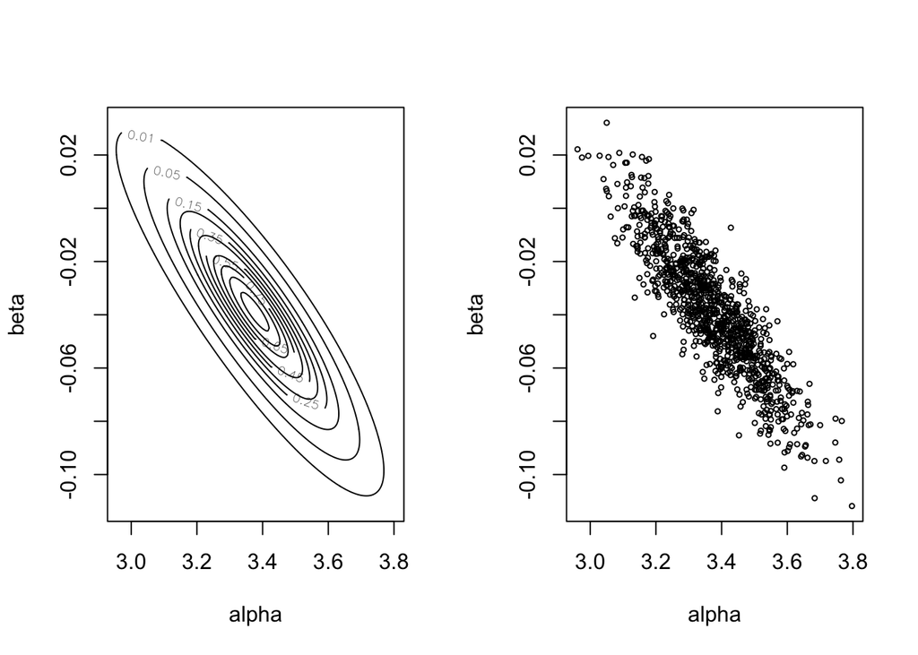

```r
# hyperprior parameters
alpha <- seq(2.5, 4, by=.005)
beta <- seq(-.15, .10, by=.001)
I <- length(alpha)
J <- length(beta)

# posteriror
log.post <- matrix(rep(NA, I*J), I, J)
for(i in 1:I){ for(j in 1:J){
  theta <- exp(alpha[i] + beta[j] * t)
  log.post[i,j] <- sum(y*log(theta) - theta)
}}
temp <- max(log.post)
log.post <- log.post - temp
post <- exp(log.post)

# Sample for posterior
delta <- (alpha[2] - alpha[1]) / 2
epsilon <- (beta[2] - beta[1]) / 2
post.ma <- apply(post, 1, sum)

S <- 1000
alpha.sim <- rep(NA, S)
beta.sim <- rep(NA, S)
for(s in 1:S){
  i <- sample(I, 1, prob=post.ma)
  j <- sample(J, 1, prob=post[i,])
  alpha.sim[s] <- alpha[i] + runif(1, -delta, delta)
  beta.sim[s] <- beta[j] + runif(1, -epsilon, epsilon)
}

par(mfrow=c(1,2))
contours <- c(.01, seq(.05, .95, .10))
contour(alpha, beta, post, levels=contours, xlim=range(alpha.sim), ylim=range(beta.sim),
        xlab="alpha", ylab="beta")
plot(alpha.sim, beta.sim, xlim=range(alpha.sim), ylim=range(beta.sim), cex=.5,
     xlab="alpha", ylab="beta")
```

3. Using your samples of (α, β), plot a histogram of the posterior density for the expected number of fatal accidents in 1986, α + 1986β.

```r
Expected1986 <- exp(alpha.sim + 11*beta.sim)
hist(Expected1986, breaks = seq(12,31,1))
temp <- quantile(Expected1986, c(.025, .975))
abline(v=temp, lty=2)
mean(Expected1986)
```

```
## [1] 19.27488
```

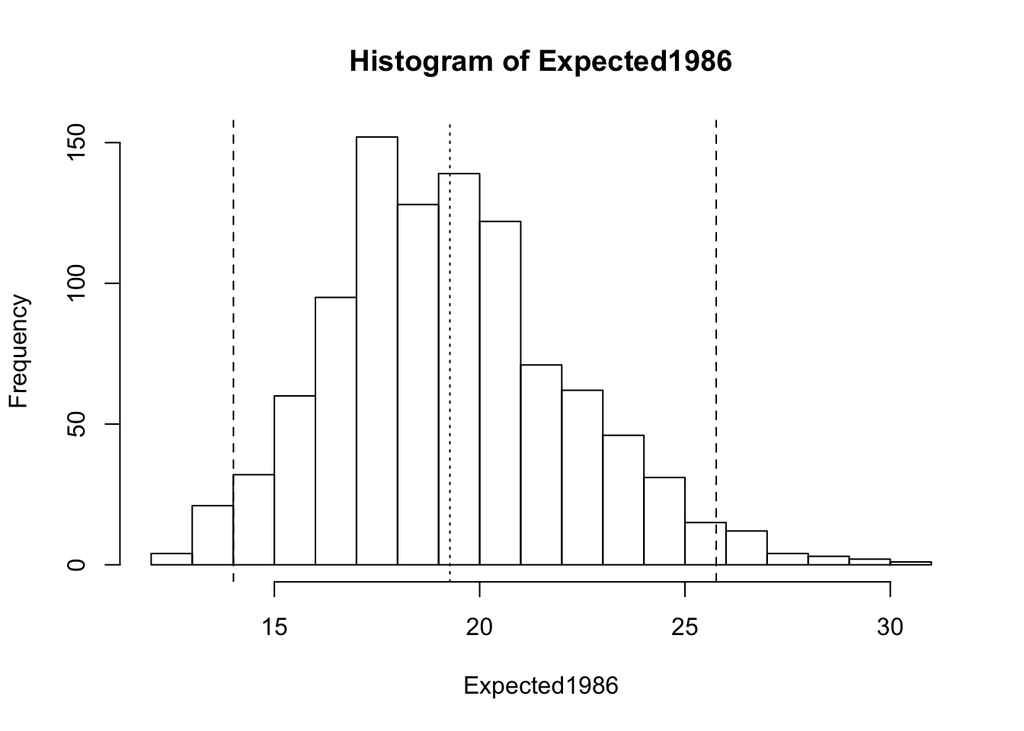

```r
abline(v=mean(Expected1986), lty=3)
```

## Quantion 4 Chapter 4 Problem 1

1. Find the posterior mode of θ by iteratively solving the equation determined by setting the derivative of the log-likelihood to zero.

```r
y <- c(43, 44, 45, 46.5, 47.5)
theta <- seq(40, 50, .01)

dlogp.dtheta <- function(theta, y){sum(2*(y-theta) / (1 + (y-theta)^2))}
theta_hat <- uniroot(dlogp.dtheta, interval=c(0, 100), y = y)$root
theta_hat
```

```
## [1] 44.86236
```

```r
d2logp.dtheta2 <- function(theta, y){
  2 * sum( ((y-theta)^2 -1) / (((y-theta)^2 + 1)^2 ))
}
theta_hat <- theta_hat - dlogp.dtheta(theta=theta_hat, y=y) / d2logp.dtheta2(theta=theta_hat, y=y)
theta_hat
```

```
## [1] 44.86235
```

```r
d2logp.dtheta2 <- function(theta, y){
  2 * sum( ((y-theta)^2 -1) / (((y-theta)^2 + 1)^2 ))
}
theta_hat <- theta_hat - dlogp.dtheta(theta=theta_hat, y=y) / d2logp.dtheta2(theta=theta_hat, y=y)
theta_hat
```

```
## [1] 44.86235
```

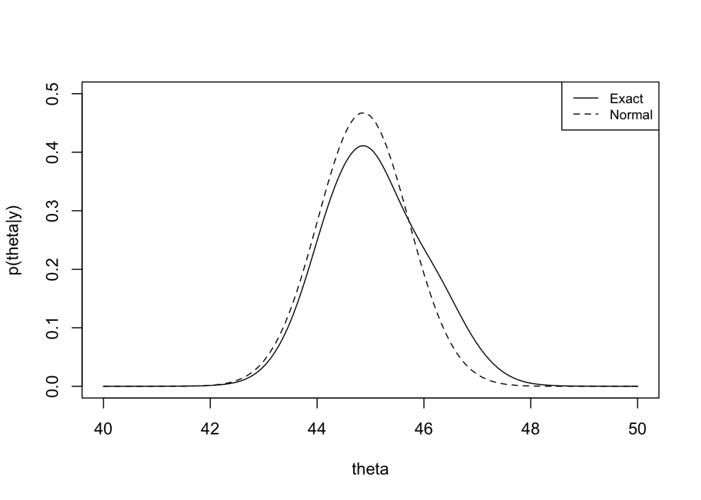

```r
# exact density computed in Exercise 2.11
log.post <- rep(NA, length(theta))
for(i in 1:length(theta)){
  log.post[i] <- sum(dcauchy(y,theta[i],log=T))
}
temp <- max(log.post)
log.post <- log.post - temp
post <- exp(log.post)
temp <- .01 * sum(post)
post <- post / temp
plot(theta, post, type="l", ylab="p(theta|y)",ylim = c(0, 0.5))

# based on the second derivative of the log posterior density at the mode.
d_2 <- -d2logp.dtheta2(theta=theta_hat, y=y)
curve(dnorm(x, mean=theta_hat, sd=1/sqrt(d_2)), lty=2, add=T)
legend("topright", lty=c(1,2), cex = 0.8,  legend=c("Exact", "Normal"))
```